# Análisis Sentimiento

Grupo MBAlentonados

23 de marzo de 2023

## Integrantes del Grupo

- Giannina Martinez Giannimartinez5@gmail.com
- Macarena Lemos lemosmacarena@gmail.com
- Silvia Maldonado maldonadosilvia21@hotmail.com
- Guillermo Auil estudioauil.asociados@gmail.com
- Nicolas Favier nfaviergonzalez@gmail.com

# A Carlos Gardel:

Milonga pa’ recordarte.  
Milonga sentimental.  
Otros se quejan llorando  
yo canto pa’ no llorar.  
Tu amor se seco de golpe  
nunca dijiste por que.  
Yo me consuelo pensando  
que fue traición de mujer.

# Politica Industrial, Desarrollo e Innovación

Las redes sociales se han convertico en la arena en la que todos podemos ver los resultados de nuestras hipotesis, sean formuladas por quien quiera de los sectores que constituyen el modelo de triple hélice.

Pólitica, entendida como una decisión tomada por anticipado es un forma de indagar las causas que provocan nuestro llanto o nuestra alegría

En momento de elecciones es vital ver cual es la visión de nuestros candidatos sobre el desarrollo y como utilizarán la innovación para llegar a ello

En este trabajo exploraremos una técnica que nos perimte compararnos con otros países y otras regiones respecto a la visión y destino que nuestros sistemas productivos locales ejercerán en nuestro futuro.

# Análisis de Sentimiento con R

En este documento revisaremos cómo realizar análisis de sentimientos usando R y el léxico Afinn.

Nos enfocaremos en algunas de las opciones que tenemos para analizar sentimientos usando R más que en los resultados específicos de los datos que usaremos, pero en el proceso veremos maneras para contestar ciertas preguntas:

No es importnte lo que veamos, lo que importa es entender como podemos tomar una montaña de datos de un corpus que puede ser desde el cuerpo legal, reglamentos, decretos etc. vinculados a la politica industrial o artículos científicos, o propuestas del tipo que imaginemos para apoyar o descartar las hipotesis de trabajo de damos por ciertas.

# Preguntas

Si hacemos una encuesta libre con los actores de una cámara industrial, un cluster o un sector representativo podemos armar un corpus con el que podremos inferir respuestas a ciertas cuestiones vitales y que sentimiento tienen los actores en torno a esos conceptos.

# Preparación

Los paquetes más importantes que usaremos son tidyverse, que nos permite importar multiples paquetes que nos facilitarán el análisis y manipulación de datos, y tidytext, que contiene las herramientas para manipular texto. Además usaremos tm contiene herramientas de mineria de textos, lubridate para fechas de manera consistente, y zoo y scales que contienen funciones para realizar tareas comunes de análisis y presentación de datos. Si no cuentas con estos paquetes, puedes obtenerlos usando la función install.packages()

# Comando

```r
# Importamos las librerías de procesamiento de texto que utilizaremos luego para poder avanzar con el análisis de sentimiento

library(tidyverse)
library(tidytext)
library(tm)
library(lubridate)
library(zoo)
library(scales)
library (knitr)
```

# Visualización

Definimos un tema para facilitar la visualización de nuestros resultados.

```r
# En este paso definimos un tema que será usado como estilo en los gráficos que serán desarrollados más adelante

tema_graf <-
  theme_minimal() +
  theme(text = element_text(family = "serif"),
        panel.grid.minor = element_blank(),
        strip.background = element_rect(fill = "#EBEBEB", colour = NA),
        legend.position = "none", legend.box.background = element_rect(fill = "#EBEBEB", colour = NA))
```

# Importando los datos

Descargamos los datos con los tuits de los candidatos a la presidencia desde la siguiente dirección, estos han sido obtenidos usando la API de Twitter.

https://raw.githubusercontent.com/jboscomendoza/rpubs/master/sentimientos_afinn/tuits_candidatos.csv

```r
# Con este comando descargamos de la url detallada las fuentes de datos que usaremos en el análisis

download.file("https://raw.githubusercontent.com/jboscomendoza/rpubs/master/sentimientos_afinn/tuits_candidatos.csv",
              "tuits_candidatos.csv")
```

# Cargas datos en memoria

Leemos los tuits usando read.csv(). El argumento fileEncoding = “latin1” es importante para mostrar correctamente las vocales con tildes, la ñ y otro caracteres especiales.

```r
# Creamos el dataset "tuits" con los datos descargados

tuits <- read.csv("tuits_candidatos.csv", stringsAsFactors = F, fileEncoding = "latin1") %>%
  as_tibble()
```

# Nuestros datos lucen así:

```r
# Luego visualizamos como se ven los datos

tuits
```

```
## # A tibble: 2,660 × 4
##    status_id created_at       screen_name   text
##        <dbl> <chr>            <chr>         <chr>
##  1   7.30e17 09/05/2016 03:03 lopezobrador_ "Proceso habla de vilezas de EPN-Ca…
##  2   7.30e17 10/05/2016 02:06 lopezobrador_ "MORENA llegó como bendición justo …
##  3   7.30e17 10/05/2016 12:00 lopezobrador_ "Muchas felicidades a las madres, t…
##  4   7.31e17 12/05/2016 04:46 lopezobrador_ "En Chihuahua, Javier Félix Muñoz, …
##  5   7.31e17 13/05/2016 02:54 lopezobrador_ "Están desatados priístas, panistas…
##  6   7.31e17 13/05/2016 19:13 lopezobrador_ "No sé a ustedes, pero a mí lo que …
##  7   7.32e17 15/05/2016 03:27 lopezobrador_ "Luego de la explosión en Pajaritos…
##  8   7.32e17 16/05/2016 02:20 lopezobrador_ "Hoy 15 de mayo nuestro sincero res…
##  9   7.32e17 17/05/2016 02:56 lopezobrador_ "El periódico Financial Times ningu…
## 10   7.33e17 18/05/2016 17:57 lopezobrador_ "Sandra Ávila Beltrán, conocida com…
## # ℹ 2,650 more rows
```

La versión que usaremos es una traducción automática, de inglés a español, de la versión del léxico presente en el conjunto de datos sentiments de tidytext, con algunas correcciones manuales. Por supuesto, esto quiere decir que este léxico tendrá algunos defectos, pero será suficiente para nuestro análisis.

# Descargamos este léxico de la siguiente dirección:

https://raw.githubusercontent.com/jboscomendoza/rpubs/master/sentimientos_afinn/lexico_afinn.en.es.csv

```r
# Realizamos el mismo proceso con las palabras de lexico afin y su respectiva puntuación según el tipo de sentimiento (valores para palabras de sentimientos positivos de 1 a 4, valores para palabras de sentimientos negativos de -1 a -4, 0 para palabras neutras)

download.file("https://raw.githubusercontent.com/jboscomendoza/rpubs/master/sentimientos_afinn/lexico_afinn.en.es.csv",
              "lexico_afinn.en.es.csv")
```

# Aplicación del léxico

De nuevo usamos la función read.csv() para importar los datos.

```r
# Creamos el dataset "afinn" con los datos descargados

afinn <- read.csv("lexico_afinn.en.es.csv", stringsAsFactors = F, fileEncoding = "latin1") %>%
  as_tibble()
```

# Este léxico luce así:

```r
# Luego visualizamos como se ven los datos

afinn
```

```
## # A tibble: 2,476 × 3
##    Palabra     Puntuacion Word
##    <chr>            <int> <chr>
##  1 a bordo              1 aboard
##  2 abandona            -2 abandons
##  3 abandonado          -2 abandoned
##  4 abandonar           -2 abandon
##  5 abatido             -2 dejected
##  6 abatido             -3 despondent
##  7 aborrece            -3 abhors
##  8 aborrecer           -3 abhor
##  9 aborrecible         -3 abhorrent
## 10 aborrecido          -3 abhorred
## # ℹ 2,466 more rows
```

```r
# Vemos que en la base de datos de léxico afin, cuando se traduce de inglés a español algunas palabras en español quedan duplicadas con 2 puntajes distintos. Vemos un ejemplo debajo:
subset(afinn, Palabra=="abatido")
```

```
## # A tibble: 2 × 3
##   Palabra Puntuacion Word
##   <chr>        <int> <chr>
## 1 abatido         -2 dejected
## 2 abatido         -3 despondent
```

```r
# Sumamos entonces este código para dejar sólo un puntaje por palabra en español. Eliminamos las palabras duplicadas agrupando y tomando el valor promedio de todas las puntuaciones que traen de las palabras a las que están asociadas en inglés:

afinn <- afinn %>% select(Palabra, Puntuacion)

afinn <- afinn %>% group_by(Palabra) %>%
  summarise(Puntuacion=mean(Puntuacion),
            .groups = 'drop')

# Corroboramos con el mismo ejemplo de arriba el resultado
subset(afinn, Palabra=="abatido")
```

```
## # A tibble: 1 × 2
##   Palabra Puntuacion
##   <chr>        <dbl>
## 1 abatido       -2.5
```

# El léxico en Español ajustado para tener sólo un puntaje por palabra luce así:

```r
# Luego visualizamos como se ven los datos con el ajuste realizado para eliminar palabras duplicadas y unificar puntuación para una misma palabra en español

afinn
```

```
## # A tibble: 2,143 × 2
##    Palabra      Puntuacion
##    <chr>             <dbl>
##  1 ""                   -2
##  2 "Angers"             -3
##  3 "Ay"                 -1
##  4 "Bamboozles"         -2
##  5 "Bastardo"           -5
##  6 "Beso"                2
##  7 "Bienvenido"          2
##  8 "Cabron"             -4
##  9 "Cabrón"             -3
## 10 "Caso omiso"         -2
## # ℹ 2,133 more rows
```

Hora de preparar nuestros datos para análisis.

# Peparando los datos

Fechas

Por último, usamos filter() de dplyr para seleccionar sólo los tuits hechos en el 2018.

```r
# Aqui sumamos información de día, mes y año para luego poder filtrar y quedarnos solo con los tuits realizados durante el 2018, el año de las eleccciones

tuits <-
  tuits %>%
  separate(created_at, into = c("Fecha", "Hora"), sep = " ") %>%
  separate(Fecha, into = c("Dia", "Mes", "Periodo"), sep = "/",
           remove = FALSE) %>%
  mutate(Fecha = dmy(Fecha),
         Semana = week(Fecha) %>% as.factor(),
         text = tolower(text)) %>%
  filter(Periodo == 2018)
```

# Convirtiendo tuits en palabras

Además, aprovechamos para crear una columna con mutate() de dplyr a las palabras como Positiva o Negativa. Llamaremos esta columna Tipo y cambiamos el nombre de la columna screen_name a Candidato.

# Analítica

```r
# En este paso transformamos cada tuit en palabras para luego cruzar cada palabra con la base de sentimientos y asignarle a cada palabra la puntuación correspondiente que denotará el sentimiento de la misma

tuits_afinn <-
  tuits %>%
  unnest_tokens(input = "text", output = "Palabra") %>%
  inner_join(afinn, ., by = "Palabra") %>%
  mutate(Tipo = ifelse(Puntuacion > 0, "Positiva", "Negativa")) %>%
  rename("Candidato" = screen_name)
```

Obtenemos también una puntuación por tuit, usando group_by() y summarise() de dplyr, y la agregamos tuits para usarla después. Tambien asignamos a los tuits sin puntuación positiva o negativa un valor de 0, que indica neutralidad. Por último cambiamos el nombre de la columna screen_name a Candidato

# Cambio Columna

```r
# Con el resultado obtenido de cada palabra, procedemos a calcular el sentimiento de cada tuit haciendo el promedio de todas las palabras que lo componen

tuits <-
  tuits_afinn %>%
  group_by(status_id) %>%
  summarise(Puntuacion_tuit = mean(Puntuacion)) %>%
  left_join(tuits, ., by = "status_id") %>%
  mutate(Puntuacion_tuit = ifelse(is.na(Puntuacion_tuit), 0, Puntuacion_tuit)) %>%
  rename("Candidato" = screen_name)
```

# Con esto estamos listos para empezar.

Explorando los datos, medias por día Empecemos revisando cuántas palabras en total y cuantas palabras únicas ha usado cada candidato con count(), group_by() y distinct() de dplyr.

# Totales

```r
# Total
tuits_afinn %>%
  count(Candidato)
```

```
## # A tibble: 5 × 2
##   Candidato         n
##   <chr>         <int>
## 1 JaimeRdzNL      446
## 2 JoseAMeadeK     462
## 3 Mzavalagc       704
## 4 RicardoAnayaC   498
## 5 lopezobrador_   138
```

# Únicas

```r
# Únicas
tuits_afinn %>%
  group_by(Candidato) %>%
  distinct(Palabra) %>%
  count()
```

```
## # A tibble: 5 × 2
## # Groups:   Candidato [5]
##   Candidato         n
##   <chr>         <int>
## 1 JaimeRdzNL      117
## 2 JoseAMeadeK     183
## 3 Mzavalagc       190
## 4 RicardoAnayaC   153
## 5 lopezobrador_    73
```

# Palabras Positivas

Y veamos también las palabras positivas y negativas más usadas por cada uno de ellos, usando map() de purr, top_n() de dplyr() y ggplot.

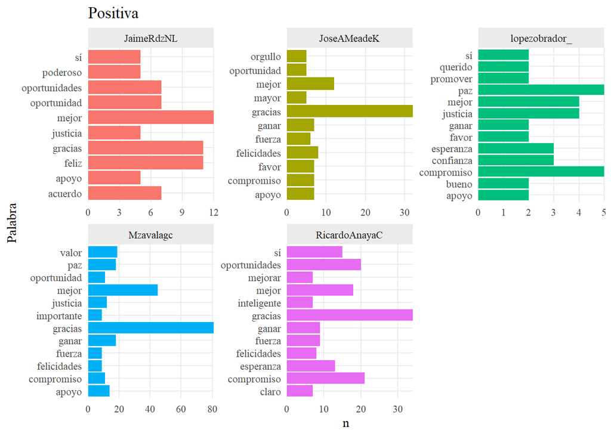

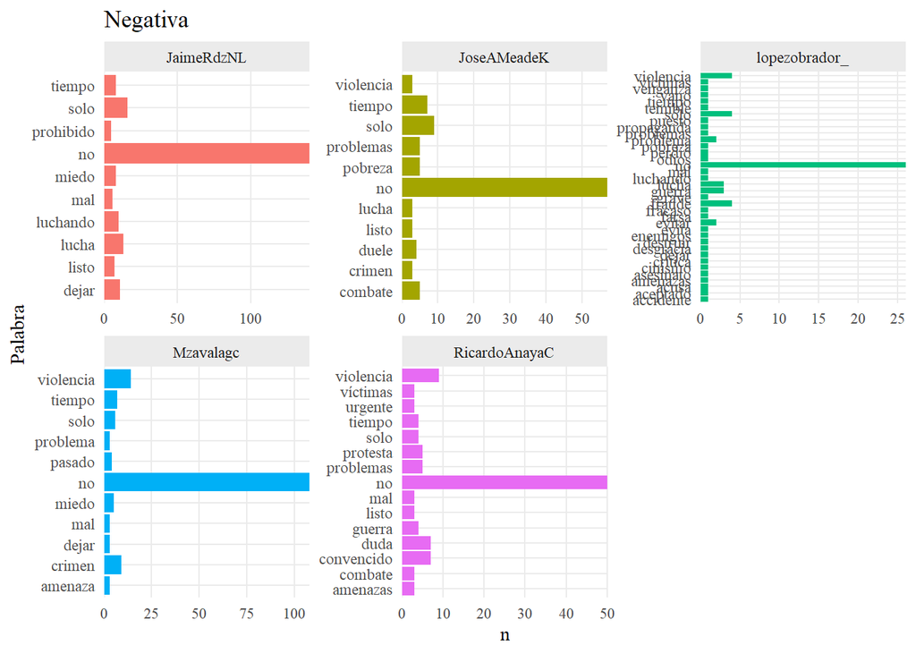

```r
# Aqui graficamos los resultados para ver tanto para las palabras positivas como las negativas, la frecuencia de uso de cada candidato

map(c("Positiva", "Negativa"), function(sentimiento) {
  tuits_afinn %>%
    filter(Tipo ==  sentimiento) %>%
    group_by(Candidato) %>%
    count(Palabra, sort = T) %>%
    top_n(n = 10, wt = n) %>%
    ggplot() +
    aes(Palabra, n, fill = Candidato) +
    geom_col() +
    facet_wrap("Candidato", scales = "free") +
    scale_y_continuous(expand = c(0, 0)) +
    coord_flip() +
    labs(title = sentimiento) +
    tema_graf
})
```

# Similitudes

Si calculamos el sentimiento de los candidatos, haciendo una suma de puntuaciones, aquellos con más palabras podrían tener puntuaciones más altas, lo cual sesgaría nuestra interpretación de la magnitud de los resultados. En un caso como este, nos conviene pensar en una medida resumen como la media para hacer una mejor interpretación de nuestros datos.

Quitamos “no” de nuestras palabras. Es una palabra muy comun en español que no necesariamente implica un sentimiento negativo. Es la palabra negativa más frecuente entre los candidatos, por lo que podría sesgar nuestros resultados.

# Resultados

```r
# Como la plabara "no" se repite varias veces, la sacamos para continuar el análisis sin considerarla

tuits_afinn <-
  tuits_afinn %>%
  filter(Palabra != "no")
```

# Tendencias

Como deseamos observar tendencias, vamos a obtener la media de sentimientos por día, usando group_by() y summarise() y asignamos los resultados a tuits_afinn_fecha

```r
# A partir de los datos que fuimos organizando, calculamos el promedio de sentimiento por día y por candidato para ver la evolución de la imagen de cada uno en el tiempo

options(dplyr.summarise.inform = FALSE)

tuits_afinn_fecha <-
  tuits_afinn %>%
  group_by(status_id) %>%
  mutate(Suma = mean(Puntuacion)) %>%
  group_by(Candidato, Fecha) %>%
  summarise(Media = mean(Puntuacion))
```

# Ploteo de resultados

Veamos nuestros resultados con ggplot()

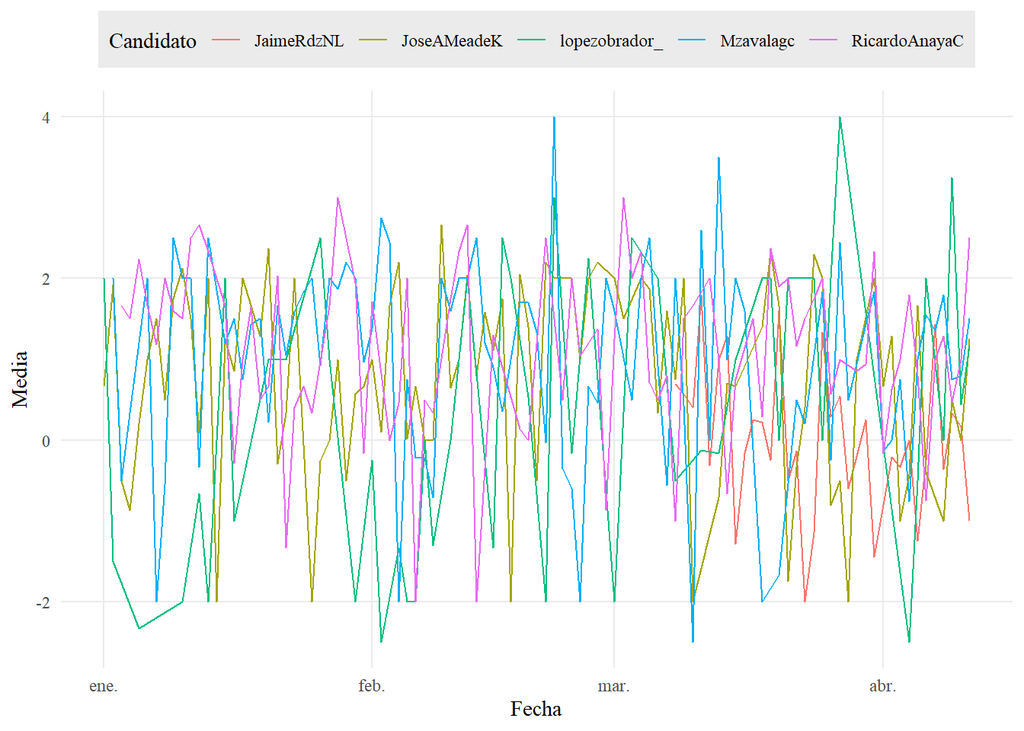

```r
# Luego graficamos los resultados para poder visualizar la evolución de la imagen de los candidatos en el tiempo

tuits_afinn_fecha %>%
  ggplot() +
  aes(Fecha, Media, color = Candidato) +
  geom_line() +
  tema_graf +
  theme(legend.position = "top")
```

# Tendencia de Candidatos

No nos dice mucho. Sin embargo, si separamos las líneas por candidato, usando facet_wrap(), será más fácil observar el las tendencias de los Candidatos.

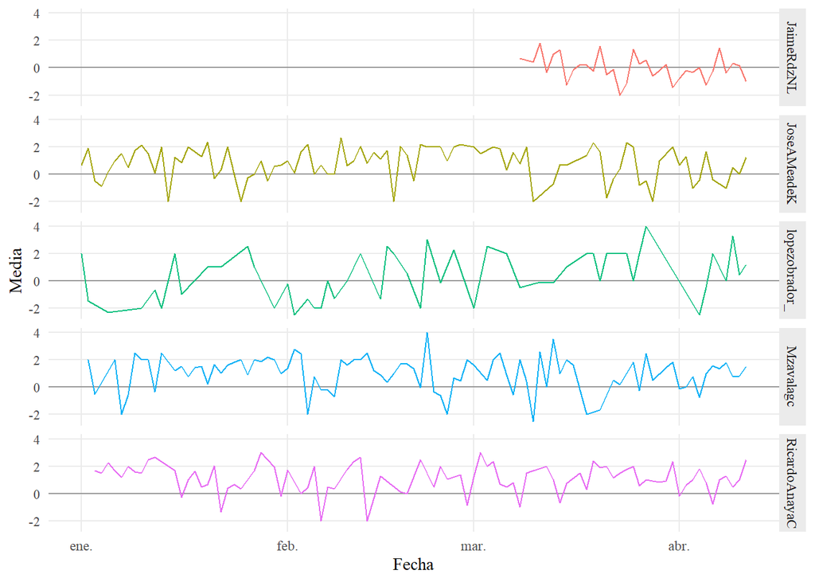

```r
# Para poder observar mejor estas evoluciones, abrimos los resultados en un gráfico por candidato

tuits_afinn_fecha %>%
  ggplot() +
  aes(Fecha, Media, color = Candidato) +
  geom_hline(yintercept = 0, alpha = .35) +
  geom_line() +
  facet_grid(Candidato~.) +
  tema_graf +
  theme(legend.position = "none")
```

# Usando LOESS (regression local)

Una manera en que podemos extraer tendencias es usar el algoritmo de regresión local LOESS. Con este algoritmo trazaremos una línea que intenta ajustarse a los datos contiguos. Como sólo tenemos una observación por día, quitaremos el sombreado que indica el error estándar.

Una explicación más completa de LOESS se encuentra aquí:

https://www.itl.nist.gov/div898/handbook/pmd/section1/pmd144.htm Usamos la función geom_smooth() de ggplot2, con el argumento method = “loess” para calcular y graficar una regresión local a partir de las medias por día.

# LOESS

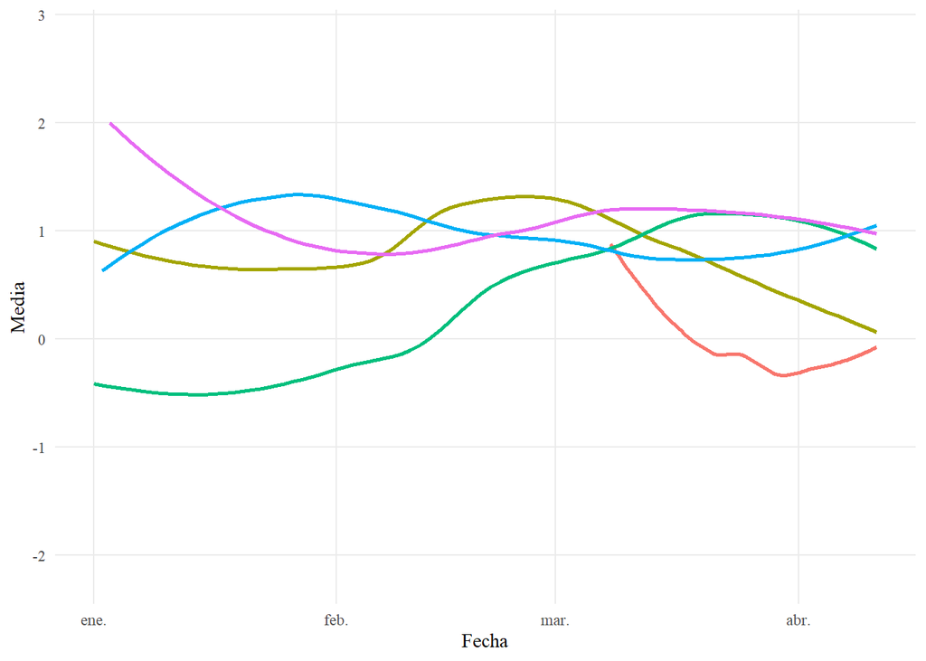

```r
# Utilizando el algoritmo de regresión local LOESS podemos observar más facilmente la tendencia de la imagen de cada candidato eliminando el "ruido" que puede generar la volatilidad diaria

tuits_afinn_fecha %>%
  ggplot() +
  aes(Fecha, Media, color = Candidato) +
  geom_smooth(method = "loess", fill = NA) +
  tema_graf
```

En realidad, podemos obtener líneas muy similares directamente de las puntuaciones.

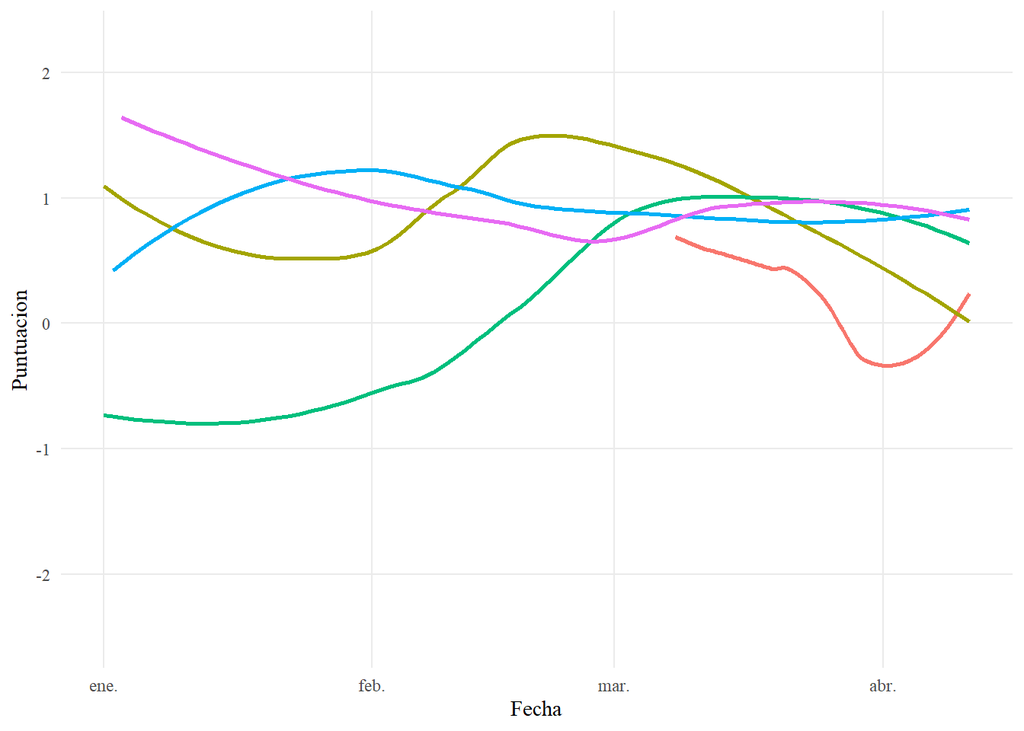

```r
tuits_afinn %>%
  ggplot() +
  aes(Fecha, Puntuacion, color = Candidato) +
  geom_smooth(method = "loess", fill = NA) +
  tema_graf
```

Si separamos las lineas por candidato y mostramos los puntos a partir de los cuales se obtienen las líneas de regresión, podemos observar con más claridad la manera en que el algoritmo LOESS llega a sus resultado. Haremos esto con facet_wrap() y geom_point.

# Tendencia

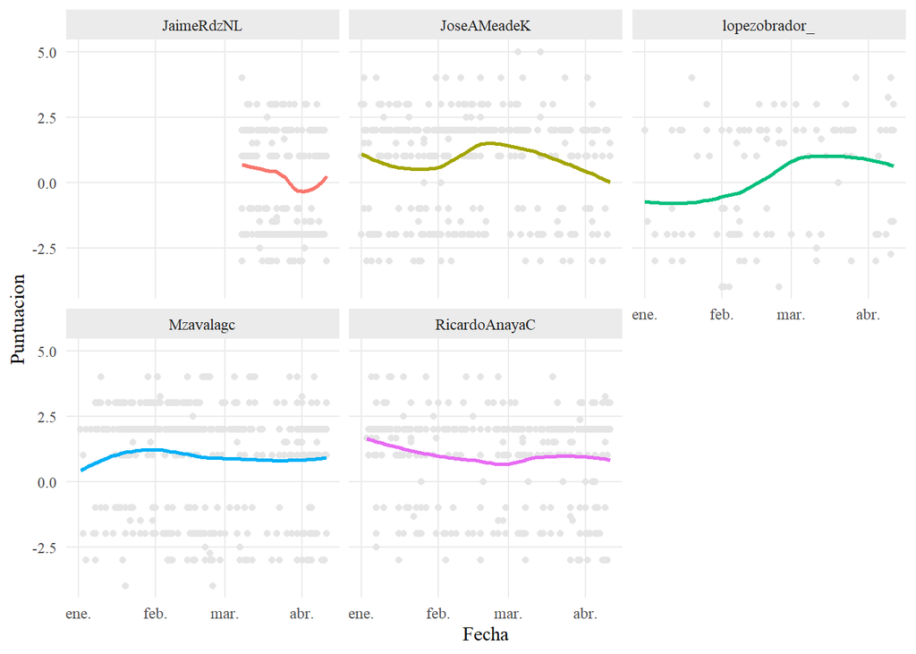

```r
# Aperturamos luego el análisis para ver cada candidato en un grafico separado y poder observar mejor la tendencia que cada uno lleva

tuits_afinn %>%
  ggplot() +
  aes(Fecha, Puntuacion, color = Candidato) +
  geom_point(color = "#E5E5E5") +
  geom_smooth(method = "loess", fill = NA) +
  facet_wrap(~Candidato) +
  tema_graf
```

**Podemos observar que si bien Lopez Obrador inició con imagen más negativa, hacia el final de la campaña fue subiendo. En cambio el candidato Jaime Rodríguez Calderón, no sólo comenzó tarde su actividad en Twitter sino que tuvo una tendencia muy hacia la imagen negativa. Los otros candidatos, tuvieron un comportamiento más estable y moderada**

# Identificación

Esto es conveniente, pues podemos identificar tendencias de datos que en apariencia no tienen ninguna. Al mismo tiempo, esto es una desventaja, pues podemos llegar a sobre ajustar la línea de regresión y, al interpretarla, llegar a conclusiones que no siempre son precisas.

Comparemos los resultados de al algoritmo LOESS con los resultados de una Regresión Lineal ordinaria, que intentará ajustar una recta.

# Ajuste Lineal

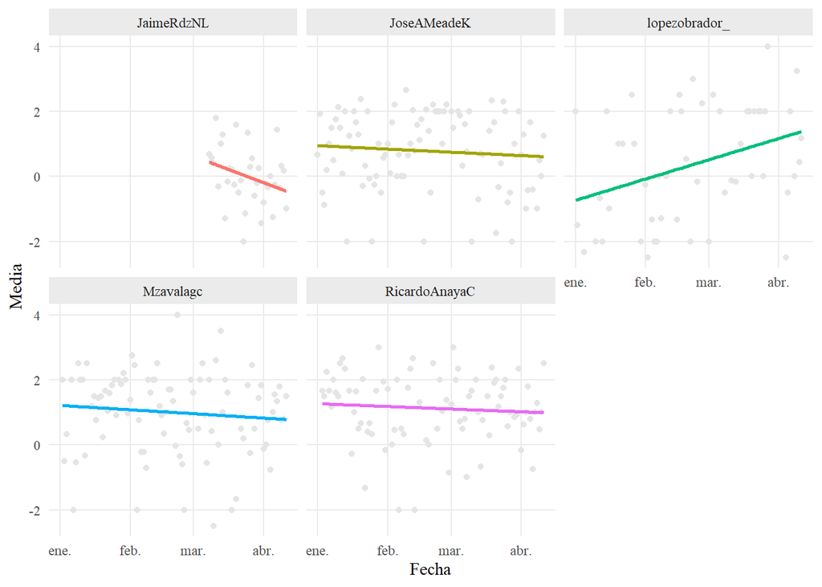

```r
# Aplicando una regresión lineal, podemos observar mejor la tendencia que mencionábamos previamente en cada candidato

tuits_afinn_fecha %>%
  ggplot() +
  aes(Fecha, Media, color = Candidato) +
  geom_point(color = "#E5E5E5") +
  geom_smooth(method = "lm", fill = NA) +
  facet_wrap(~Candidato) +
  tema_graf
```

**Tomando otro caso como ejemplo, hemos encontrado el análisis de sentimiento de la campaña 2020 en Estados Unidos donde compitieron Biden y Trump. En la web con los resultados de los análisis de sentimientos llevados a cabo, tomando como base los tweets que fueron analizados vemos como las tendencias del análisis daban un sentimiento más positivo para Biden que para Trump. Luego el resultado de la elección terminó por darlo ganador a Biden**

**Debajo podemos ver el gráfico del análisis de sentimiento para Trump y Biden en fechas próximas a la elección**

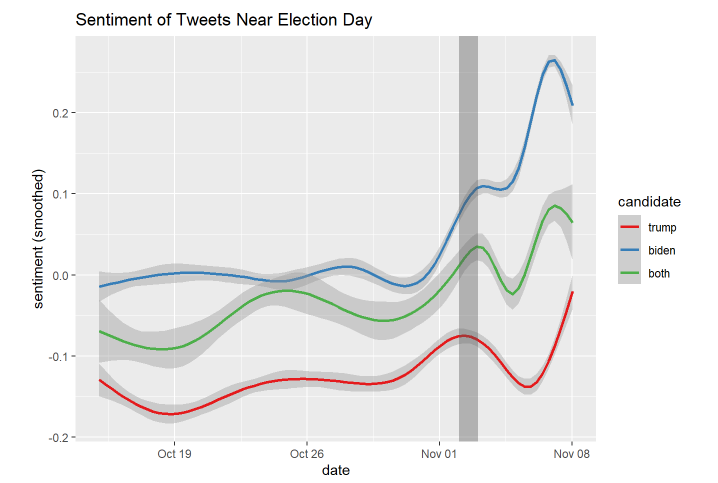

**El mismo análisis hecho enfocando en los días previos nos permite ver que la tendencia se mantiene**

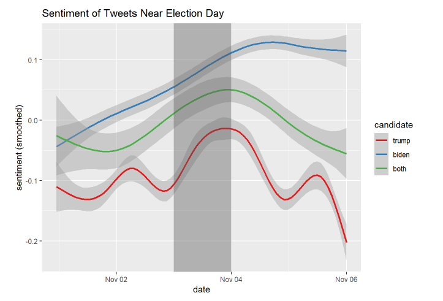

**Fuente:**

https://webpages.csus.edu/fitzgerald/assets/2020_tweet_sentiment_aleksey.html

# Clarificación

Aun podemos observar una tendencia, pero en la mayoría de los casos no es tan “clara” como parecería usando LOESS. También podemos ver cómo es que pocos datos, es posible que valores extremos cambien notablemente la forma de una línea trazada con LOESS, de manera similar a cómo cambian la pendiente de una Regresión Lineal ordinaria. Esto es osbervable con los datos de lopezobrador_.

Para nuestros fines, LOESS es suficiente para darnos un panorama general en cuanto a la tendencia de sentimientos en los candidatos. No obstante, es importante ser cuidadosos con las interpretaciones que hagamos.

# Usando la media móvil

La media móvil se obtiene a partir de subconjuntos de datos que se encuentran ordenados. En nuestro ejemplo, tenemos nuestros datos ordenados por fecha, por lo que podemos crear subconjuntos de fechas consecutivas y obtener medias de ellos. En lugar de obtener una media de puntuación de todas las fechas en nuestros datos, obtenemos una media de los días 1 al 3, después de los días 2 al 4, después del 3 al 5, y así sucesivamente hasta llegar al final de nuestras fechas.

Lo que obtendríamos con esto son todos los agregados de tres días consecutivos, que en teoría debería ser menos fluctuantes que de los días individuales, es decir, más estables y probablemente más apropiados para identificar tendencias.

Crearemos medias móviles usando rollmean() de zoo. Con esta función calculamos la media de cada tres días y la graficamos con ggplot.

# Media Móvil

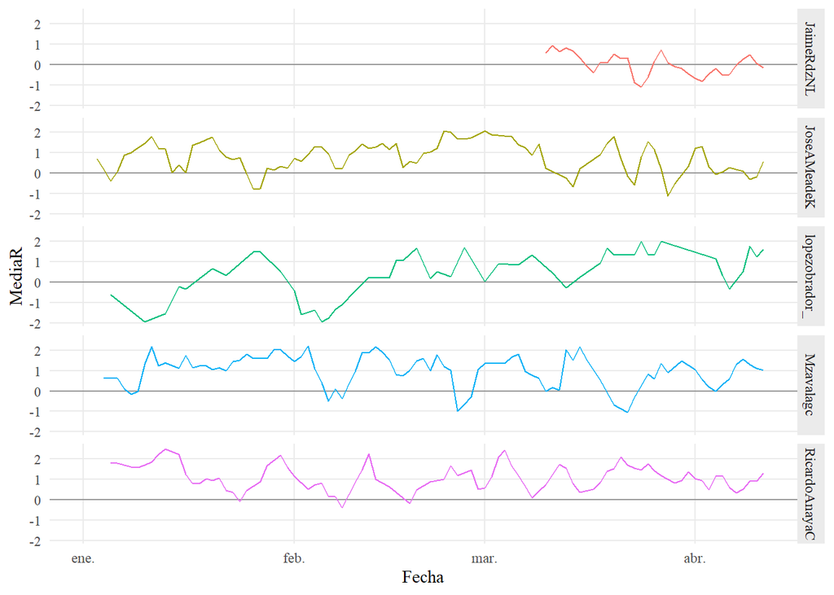

```r
# A los fines de confirmar las conclusiones del análisis ahora corremos un proceso de medias móviles para refinar los datos y poder validar las tendencias mencionadas previamente

tuits_afinn_fecha %>%
  group_by(Candidato) %>%
  mutate(MediaR = rollmean(Media, k = 3, align = "right", na.pad = TRUE)) %>%
  ggplot() +
  aes(Fecha, MediaR, color = Candidato) +
  geom_hline(yintercept = 0, alpha = .35) +
  geom_line() +
  facet_grid(Candidato~.) +
  tema_graf
```

**Podemos observar que aplicando el método de medias móviles, también observamos la tendencia a la suba en el sentimiento positivo de Lopez Obrador hacia el final del proceso de elecciones, mientras que la imagen del resto de los candidatos mostraba una tendencia más a la baja, más allá de la volatilidad diaria**

# Comparación de Gráficas

Si comparamos con la gráfica que obtuvimos a partir de las medias por día, esta es menos “ruidosa” y nos permite observar más fácilmente las tendencias.

Comparando sentimientos positivos y negativos Es posible que no nos interen las puntuaciones de sentimiento de cada día, sólo si la tendencia ha sido positiva o negativa. Como ya etiquetamos la puntuación de nuestros tuits como “Positiva” y “Negativa”, sólo tenemos que obtener proporciones y graficar.

Primero, veamos que proporción de tuits fueron positivos y negativos, para todo el 2018 y para cada Candidato. Usamos geom_col() de ggplot2 para elegir el tipo de gráfica y la función percent_format() de scales para dar formato de porcentaje al eje y.

# Proporciones

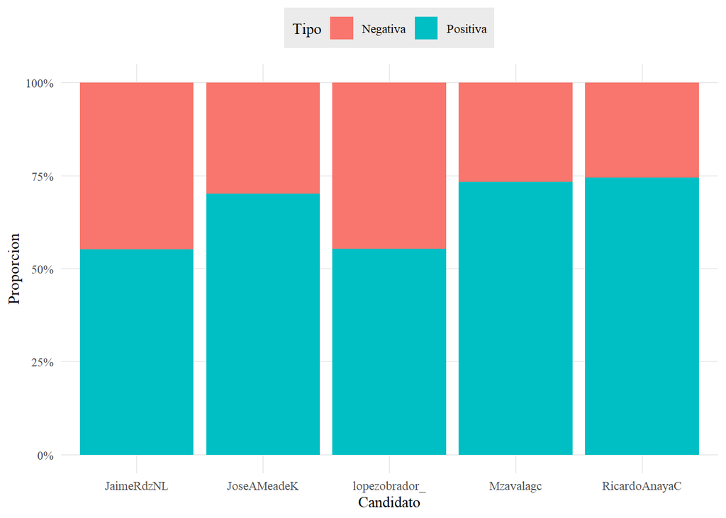

```r
# Otro análsis que podemos hacer es analizar que cantidad de palabras positivas vs negativas realizó cada candidato

tuits_afinn %>%
  count(Candidato, Tipo) %>%
  group_by(Candidato) %>%
  mutate(Proporcion = n / sum(n)) %>%
  ggplot() +
  aes(Candidato, Proporcion, fill = Tipo) +
  geom_col() +
  scale_y_continuous(labels = percent_format()) +
  tema_graf +
  theme(legend.position = "top")
```

**Vemos que todos tienen una tendencia a usar palabras positivas en mayor medida que las negativas lo que puede entenderse debido a la circunsatancia en la que se están comunicando, tratando de generar confianza en el electorado**

# Imagen positiva y Negativa

Si obtnemos la proporción de positiva y negativa por día, podemos obsrvar cómo cambia con el paso del tiempo. Usamos el argumento width = 1 de geom_col() para quitar el espacio entre barras individuales y el argumento expand = c(0, 0) de scale_x_date() para quitar el espacio en blanco en los extremos del eje x de nuestra gráfica (intenta crear esta gráfica sin este argumento para ver la diferencia).

# Imagen Positiva y Negativa por Fecha

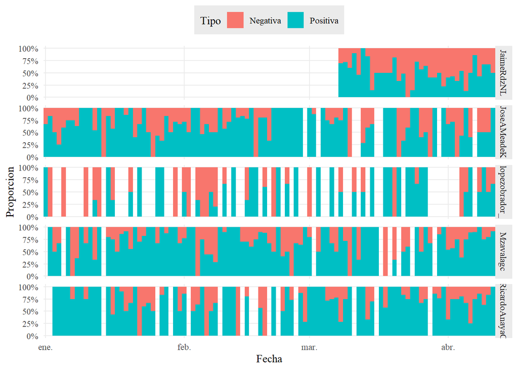

```r
# Este mismo análisis pero aperturado por fecha nos permite ver los comportamientos en los días más cercanos a las elecciones

tuits_afinn %>%
  group_by(Candidato, Fecha) %>%
  count(Tipo) %>%
  mutate(Proporcion = n / sum(n)) %>%
  ggplot() +
  aes(Fecha, Proporcion, fill = Tipo) +
  geom_col(width = 1) +
  facet_grid(Candidato~.) +
  scale_y_continuous(labels = percent_format()) +
  scale_x_date(expand = c(0, 0)) +
  tema_graf +
  theme(legend.position = "top")
```

En este ejemplo, como los candidatos no tuitearon todos los días, tenemos algunos huecos en nuestra gráfica. De todos modos es posible observar la tendencia general de la mayoría de ellos.

# Bloxplots (diagrama caja y bigotes)

Una manera más en la que podemos visualizar la puntuación sentimientos es usando boxplots. En nuestro análisis quizás no es la manera ideal de presentar los resultados dado que tenemos una cantidad relativamente baja de casos por Candidato. Sin embargo, vale la pena echar un vistazo, pues es una herramienta muy útil cuando tenemos una cantidad considerable de casos por analizar.

En este tipo de gráficos, la caja representa el 50% de los datos, su base se ubica en el primer cuartil (25% de los datos debajo) y su tope en el tercer cuartil (75% de los datos debajo). La línea dentro de la caja representa la mediana o secundo cuartil (50% de los datos debajo). Los bigotes se extienden hasta abarcar un largo de 1.5 veces el alto de la caja, o hasta abarcar todos los datos, lo que ocurra primero. Los puntos son los outliers, datos extremos que salen del rango de los bigotes. Por todo lo anterior, esta visualización es preferible cuando tenemos datos con distribuciones similares a una normal.

Usamos la función geom_boxplot() de ggplot2 para elegir el tipo de gráfica. Creamos un boxplot por candidato.

# Boxplot

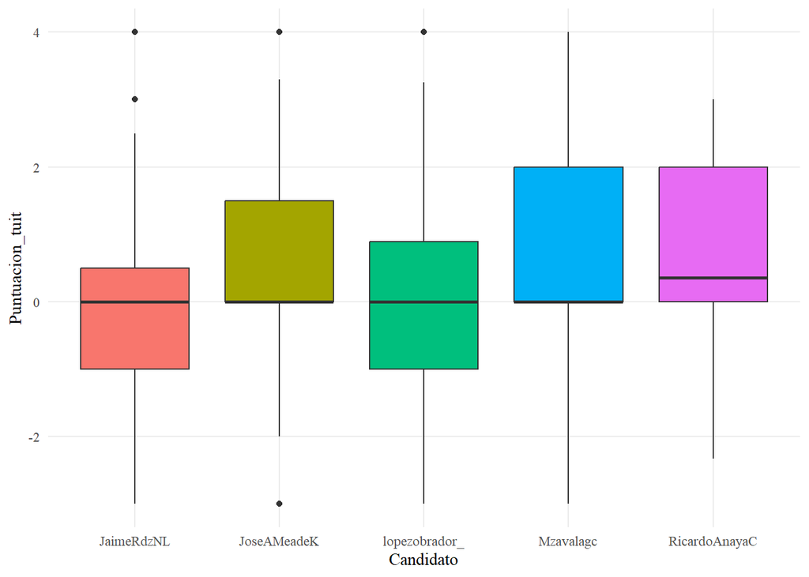

```r
# Otra forma de análisis es el diagrama boxplot. En el gráfico podemos ver la distribución de los tuits de cada candidato en lo que respecta a la puntuación de sentimiento

tuits %>%
  ggplot() +
  aes(Candidato, Puntuacion_tuit, fill = Candidato) +
  geom_boxplot() +
  tema_graf
```

# Dinámica de los cambios

También podemos crear boxplots para ver cambios a través del tiempo, sólo tenemos que agrupar nuestros datos. Como nuestros datos ya tienen una columna para el mes del año, usaremos esa como variable de agrupación. Nota que usamos factor() dentro de mutate() para cambiar el tipo de dato de Mes, en R los boxplots necesitan una variable discreta en el eje x para mostrarse correctamente.

# Dinámica

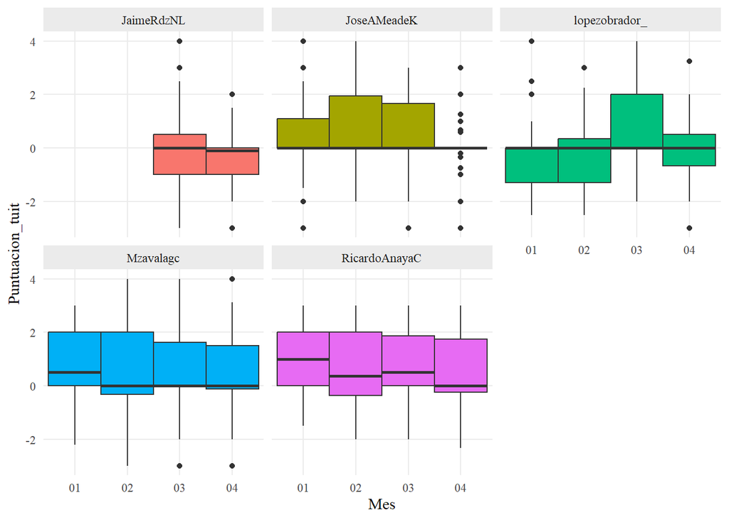

```r
# Sumando la variable temporal, podemos ver este mismo análisis para entender la evolución mensual de los sentimientos de los tuits

tuits %>%
  mutate(Mes = factor(Mes)) %>%
  ggplot() +
  aes(Mes, Puntuacion_tuit, fill = Candidato) +
  geom_boxplot(width = 1) +
  facet_wrap(~Candidato) +
  tema_graf +
  theme(legend.position = "none")
```

# Usando densidades

Por último, podemos analizar las tendencias de sentimientos usando las funciones de densidad de las puntuaciones. ggplot2 tiene la función geom_density() que hace muy fácil crear y graficar estas funciones.

# Densidad

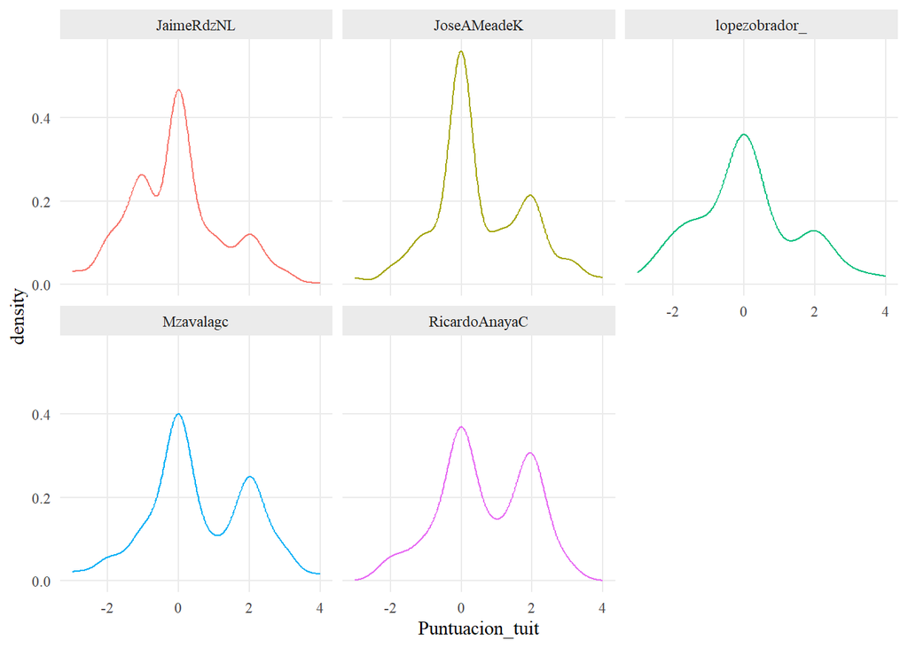

```r
# Este análisis nos permite ver la distribución de los sentimientos de cada candidato para entender mejor que tipo de puntuación de sentimiento se dieron con más frecuencia

tuits %>%
  ggplot() +
  aes(Puntuacion_tuit, color = Candidato) +
  geom_density() +
  facet_wrap(~Candidato) +
  tema_graf
```

# Tendencias Dinámicas

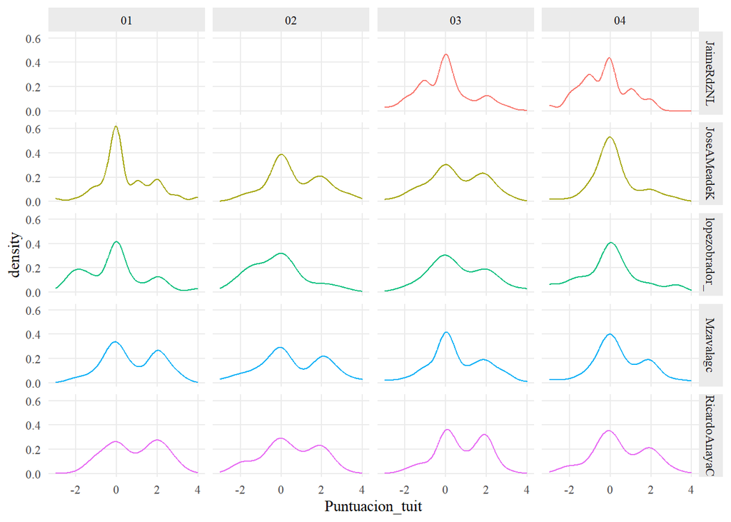

```r
# Continuando con el análisis, sumando la variable temporal, podemos ver la evolución mes a mes

tuits %>%
  ggplot() +
  aes(Puntuacion_tuit, color = Candidato) +
  geom_density() +
  facet_grid(Candidato~Mes) +
  tema_graf
```

# Para concluir

En este artículo revisamos algunas de las estrategias principales para analizar sentimientos con R, usando el léxico Afinn. Este léxico le asigna una puntuación a las palabras, de acuerdo a su contenido, que puede ser positivo o negativo.

En realidad, que la puntuación sea de tipo numérico es lo nos abre una amplia gama de posibilidades para analizar sentimientos usando el léxico Afinn. Con conjuntos de datos más grandes que el que usamos en este ejemplo, es incluso plausible pensar en análisis más complejos, por ejemplo, establer correlaciones y crear conglomerados.

Aunque no nos adentramos al análisis de los resultados que obtuvimos con nuestros datos, algunas tendencias se hicieron evidentes rápidamente. Por ejemplo, la mayoría de los candidatos ha tendido a tuitear de manera positiva. Con un poco de conocimiento del tema, sin duda podríamos encontrar información útil e interesante.

**Vemos como este trabajo nos permitió entender mejor el funcionamiento de herramientas para el análsis de sentimiento. Adicionalmente, los datos nos brindan información interesante sobre el comportamiento de los candidatos de la elección y su interacción con las redes sociales. Vemos como esta herramienta puede ser de mucha utilidad para identificar tendencias y patrones de comportamiento que podrían dar señales sobre la probabilidad de éxito de un candidato por sobre otro**